# Movilidad urbana en México: ¿Quién viaja, cómo y por qué?

Author

Fernando Pavía-González, Fernando Ramos-Valdez, Jorge Sanchez-Ponce, Mateo Yáñez-Tanaka

## Abstract

This study analyzes urban mobility patterns in Mexico City to better understand who travels, how, and why. The main objective is to identify probabilistic relationships between sociodemographic variables and modes of transport, providing insights that may inform public policy and mobility planning. To achieve this, Bayesian Networks (BNs) were employed, allowing the modeling of conditional dependencies among factors such as age, gender, socioeconomic status, locality population, vehicle ownership, and type of transport used. The methodology combined data preprocessing with Python and statistical inference with R, using data from the Encuesta Origen-Destino en Hogares de la Zona Metropolitana del Valle de México (2017). Different Directed Acyclic Graphs (DAGs) were generated—based on theoretical assumptions, empirical evidence, and algorithmic optimization (Hill Climbing)—and later compared through Bayesian Information Criterion (BIC) and Akaike Information Criterion (AIC). Results show that young women from high socioeconomic backgrounds are unlikely to use bicycles, while nearly half of the lower-income population owns at least one private vehicle. Additionally, about 30% of individuals in small localities (<2,500 inhabitants) belong to high socioeconomic levels, and men and women from low-income groups between 40–99 years tend to walk with almost identical frequency during weekdays. These findings underscore the relevance of demographic and socioeconomic factors in shaping urban mobility choices. The conclusions highlight the implications for designing safer, more sustainable, and inclusive transport systems, while acknowledging the limitation of using 2017 data and the need for more recent and comprehensive datasets.

## Introducción

El movimiento es una parte importante de la vida diaria de las personas. Desde llegar al trabajo hasta visitar a la familia, la forma en la que llegamos a lugares determina gran parte de nuestras vidas. En tiempos recientes los cambios poblacionales, y la planeación urbana han llevado a que el tiempo de transporte en las ciudades se vuelva irracional para los trayectos que se cubren. La falta de y sobrecarga en las vías de transporte público además de la comodidad y poca regulación sobre el transporte privado no colaboran con este problema. El objetivo de esta investigación es comprender mejor los patrones de transporte de la población para informar la toma de decisiones en las políticas públicas y reducir la duración de los trayectos.

Investigaciones previas han encontrado que desde inicios de la pandemia del COVID-19 en el 2020 las tendencias del transporte tanto en méxico como en otros países de américa latina han cambiado. Desde la declaración de la pandemia el comportamiento de la movilidad de las ciudades más grandes de américa latina y el resto del mundo se minimizaron, limitando la asistencia a lugares de trabajo y estudio principalmente. Los niveles de asistencia a espacios de trabajo no alcanzaron los números vistos en febrero de 2020 hasta el segundo semestre del 2021.( Bosisio and Talavera García (2025) )

Estas tendencias de inmovilidad también provocaron un cambio en las dinámicas de movilidad, transportes públicos redujeron sus viajes por el riesgo a contagio y la fuerte necesidad de realizar compras sin salir del hogar provocó que servicios de delivery y paquetería aumentaran sus actividades. Un claro indicador de esto es el creciente aumento en la adquisición y uso de motocicletas en México, que incrementó un 473% desde el 2010 hasta el 2020 y se vió inmediatamente superado en 2021 con un aumento del 20% con respecto al año anterior.

Como es evidente para este punto el panorama de la movilidad especialmente en la república mexicana, levanta muchas preocupaciones en temas como la seguridad vial, concientización ecológica y derivados. Tenemos en frente una transformación en la forma en la que los mexicanos abordamos el desplazamiento dentro de la ciudad, es por esto que entender los patrones de transporte basándonos en características demográficas de la población podría ayudarnos a obtener perspectiva en formas de acción para combatir las necesidades más presentes en los transeúntes.

Para comprender estos patrones de desplazamiento se determinó que se contestarán un total de 4 preguntas propuestas por otros grupos de investigadores en nuestro grupo de estudio.

- ¿Cuál es la probabilidad de que una mujer joven de estrato social alto use la bicicleta?
- ¿Cuál es la probabilidad de que una persona que vive en una localidad de menos de 2,500 habitantes sea de estrato alto?
- ¿Cuál es la probabilidad de que alguien de estrato sociodemográfico bajo tenga ya sea una moto, un auto o una bicicleta?
- Se busca averiguar si las mujeres de edad media y alta, de estrato social bajo tienden a caminar más entre semana en comparación a los hombres con las mismas características.

Se espera que al determinar la probabilidad de que estos sucesos ocurran obtengamos una mejor percepción de las inclinaciones de la población con respecto a sus métodos de transporte.

## Metodología

Esta investigación se centró en encontrar las probabilidades de ciertos eventos que podrían ayudar a comprender mejor los patrones de movimiento de la población basado en sus características sociodemográficas. Para ello se utilizaron las redes bayesianas (BNs por sus siglas en inglés). Estas estructuras son gráfos dirigidos acíclicos (DAGs por sus siglas en inglés) en los cuales todos los nodos representan variables aleatorias (ya sea discretas o continuas) y los arcos, junto con su dirección, representan dependencias condicionales. Las BNs permiten trabajar con distribuciones condicionales locales
$$A \sim \text{Mult}(n,\theta_{A})$$
en vez de la distribución conjunta (global)
$$X \sim \text{Mult}(n,p)$$
la cual es más compleja. Las BNs también nos dan el beneficio de poder realizar *queries*, una forma de inferencia para encontrar probabilidades del estilo
$$\mathbb{P}(Evento|Evidencia)$$
a través de aproximaciones (con algoritmos como logic sampling o muestreo de Monte Carlo) o de manera exacta (con algoritmos como variable elimination y junction tree). ( Garrido Guillén (2025) )

Las DAGs son modelos evaluables a través de varios métodos. Para esta investigación se utilizaron el *Bayesian Information Criterion* (BIC) que está dado por
$$BIC = \ln[\mathbb{\hat{P}}(Nodos)] -\frac{d}{2}\ln(n)$$
y el *Akaike Information Criterion* (AIC) dado por
$$AIC = \ln[\mathbb{\hat{P}}(Nodos)] -d$$
donde $\mathbb{\hat{P}}(Nodos)$ es la probabilidad global estimada, $d$ es el numero total de parámetros y $n$ es el número de oservaciones. Las DAGs también pueden ser optimizadas a través del algoritmo de búsqueda avariciosa *Hill Climbing* sin embargo los resultados de estos no siempre tienen sentido en su contexto. ( Garrido Guillén (2025) )

Para la creación de los modelos computacionales se usaron los lenguajes R y Python. Python se usó para la limpieza y unificación de los datos, mientras que R se usó para la inferencia estadística. Los módulos necesarios para replicar esta investigación son:

Para python:

- `pandas` para el procesamiento de los datos
- `numpy` para el manejo de arrays

Para R:

- `bnlearn` para el entrenamiento de las redes bayesianas
- `rgraphviz` para graficar las dags

Adicionalmente los datos usados para esta investigación provienen de Instituto Nacional de Estadística y Geografía, y su [Encuesta Origen Destino en Hogares de la Zona Metropolitana del Valle de México (EOD) 2017](https://www.inegi.org.mx/programas/eod/2017/#documentacion)

## Aplicación

### Limpieza de Datos

Este Proyecto comenzó importando la base de datos, que se encontraba separada en cinco archivos distintos. Tras leer sus catálogos determinamos que para efectos de esta investigación no todas las variables contenidas dentro de estos nos eran útiles, las que conservamos fueron aquellas que representan la cantidad de vehículos que poseé una persona, su estrato socioeconómico, edad y sexo, y finalmente la población de la localidada donde vive, el día en el que viajó, y el vehículo que usó. Después de hacer esto se cambió el esquema de los nombres para que fuesen únicamente letras que representan las variables y la forma en la que estaba categorizada la edad para que fuesen categorías más amplias que los años cumplidos. (Para más información ver el archivo auxiliar [Generación de Datos](https://github.com/Mattanaka343/Situaci-n-Problema-Transporte/blob/main/Notebooks/DataGeneration.ipynb)

### Formulando DAGs

Después de esto se importaron los datos en R y se formuló una DAG preliminar basada en intuiciones sobre el transporte. Teorizamos que la edad (E) y el sexo (S) son los nodos raíz e independientes entre ellos. El estrato socioeconómico (C) está dado por la edad y el sexo; este mismo se relaciona con la cantidad de vehículos privados que la persona poseé (A)(B)(M) y define la población dentro de su localidad (L). La cantidad de vehículos y la localidad (L) informan el vehículo que se utiliza en un viaje (V) y finalmente, el día del viaje (D) está dado por el vehículo que se usa en dicho él.

```r
install.packages('bnlearn')
install.packages('BiocManager')
install.packages('')
BiocManager::install('Rgraphviz')
```

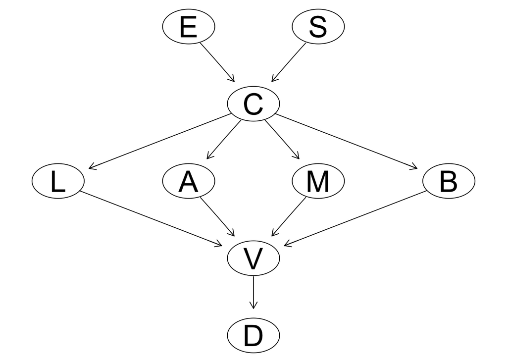

```r
library(bnlearn)
library(tidyverse)
set.seed(42)

data = read.csv('../Data/datos.csv',)
data = data |> select(-id_viv)

int_cols = sapply(data,is.integer)
data[int_cols] = lapply(data[int_cols],as.factor)

dag = empty.graph(nodes = c('L','C','A','M','B','D','E','V','S'))

arc_set = matrix(c("E","C",
                   "S","C",
                   "C","A",
                   "C","M",
                   "C","B",
                   "C","L",
                   "A","V",
                   "M","V",
                   "B","V",
                   "V","D",
                   "L","V"), byrow = TRUE, ncol = 2,
                 dimnames = list(NULL, c("from", "to")))

arcs(dag) = arc_set
graphviz.plot(dag,shape = 'ellipse')
```

Después de esto para corroborar la validez del modelo dados nuestros datos se obtuvo la fuerza de cada noodo usando el método `arc.strength()` y se generó una segunda DAG.

```r
arc.strength(dag, data = data, criterion = "mi")
```

| from | to | strength |
| --- | --- | --- |
| E | C | 0 |
| S | C | 0 |
| C | A | 0 |
| C | M | 0 |
| C | B | 0 |
| C | L | 0 |
| A | V | 0 |
| M | V | 1 |
| B | V | 1 |
| V | D | 0 |
| L | V | 1 |

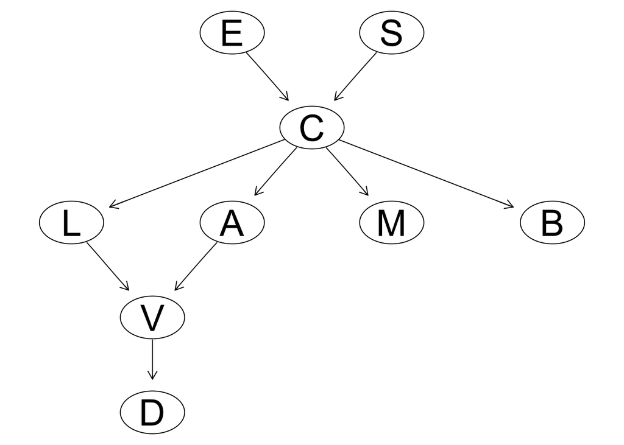

```r
dag2 = empty.graph(nodes = c('L','C','A','M','B','D','E','V','S'))

arc_set2 = matrix(c("E","C",
                   "S","C",
                   "C","A",
                   "C","M",
                   "C","B",
                   "C","L",
                   "A","V",
                   "V","D",
                   "L","V"), byrow = TRUE, ncol = 2,
                 dimnames = list(NULL, c("from", "to")))

arcs(dag2) = arc_set2

graphviz.plot(dag2, shape = "ellipse")
```

Esta DAGG implica que lo único que informa el vehículo en el que viaja una persona es la cantidad de carros que poseé y la localidad en la que recide.

Después se construyó una basada en investigación. Para esta DAG se consultaron varios recursos y artículos que describien la relación entre las variables seleccionadas para el modelado. Estos estudios si bien varían entre varios países en distintos niveles de desarrollo, otorgan una perspectiva generalizada que servirá como base para describir las conductas que podemos observar en el mundo y aplicarlas a nuestra colección de datos.

En primer lugar partiremos de los “Nodos Padre” principales como las variables que no dependen de otras, entre ellas se encuentran el sexo (S), la edad (E), el tamaño de la población de la localidad (L) y por ultimo el estrato social (C). Las primeras tres variables por simple lógica no se ven influenciadas por ninguna otra variable ya que son estados definidos e independientes tanto de la personas como de las localidades. Aunque se podría argumentar que en el estrato social influyen aspectos como el nivel de educación, los ingresos e incluso variables que poseemos como el sexo y la edad, se consideró que dada la limitación con las variables elegidas, la relación no sería tan significativa y solo volvería la DAG más ineficiente para la modelación.

Partiendo de esta base se definieron las primeras relaciones con las variables que describen la cantidad de motos (M), bicicletas (B) y automóviles (C). Las relaciones de dependencia directas que se ven definidas a partir de los nodos padre y basados en nuestra investigación indican que existe una relación entre el estrato social y todas las anteriormente mencionadas. Un mayor nivel de estudio y mayor poder adquisitivo en el jefe de la familia aumenta la cantidad de vehículos en el hogar. Por otra parte la edad parece estar relacionada a la cantidad de bicicletas en el hogar, esto debido a que principalmente niños y adultos jóvenes son los que tienden a utilizar este medio de transporte.( Rith, Fillone, and Biona (2019) )( H.-C. Yang et al. (2023) ) Finalmente el tamaño de la población tiene un efecto en la cantidad de autos en el hogar debido a las diferencias en la forma urbana que las localidades presentan de acuerdo a su población. Tanto la facilidad de tránsito en las calles como el acceso a transporte público es otra diferencia muy notoria de localidad a localidad. ( Zhang et al. (2018) )

Para la próxima variable dentro de la DAG que indica el medio de transporte utilizado en un determinado viaje, podemos relacionar la cantidad de vehículos de cada categoría dentro de un hogar (M,B y C), debido a que contar con estos medios de transporte privados tiene una influencia directa en la toma de decisiones a la hora de seleccionar el modo de desplazamiento. ( Dissanayake and Morikawa (2010) ) ( Timpabi, Kwakwa, and Adams (2021) ) Finalmente la variable del sexo (S) también posee una relación con el modo de transporte. Esto está mas arraigado en las diferencias sociales entre hombres y mujeres, dado que en muchas ocasiones las mujeres evitan ciertos medios por las implicaciones en su seguridad y bienestar, además que suelen trasladarse con niños y esto también afecta el medio que usan. ( M. Yang et al. (2013) )

La última variable (D) que especifica el periodo de la semana en que se realizó el viaje (entre semana o sábado), solo está relacionada con el medio de transporte utilizado para el viaje, ya que las actividades realizadas en distintos días de la semana requieren de un vehículo o medio de transporte adecuado. Como lo explica el estudio de Raux, et al. la distribución y cantidad de localizaciones a visitar dentro de un “tour” se diferencia mucho entre fines de semana y días entre semana presentando mucha variabilidad intrapersonal, concretamente en fines de semana, cambiando las distancias a recorrer y por lo tanto el medio de transporte utilizado. ( Raux, Ma, and Cornelis (2016) )

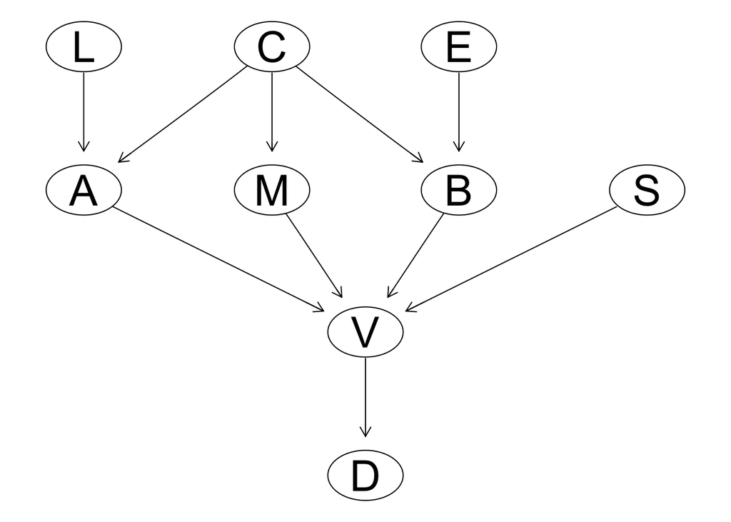

```r
dag3 = empty.graph(nodes = c('L','C','A','M','B','D','E','V','S'))

arc_set3 = matrix(c("E","B",
                   "C","A",
                   "C","M",
                   "C","B",
                   "L","A",
                   "B","V",
                   "A","V",
                   "M","V",
                   "S","V",
                   "V","D"
                   ), byrow = TRUE, ncol = 2,
                 dimnames = list(NULL, c("from", "to")))

arcs(dag3) = arc_set3

graphviz.plot(dag3, shape = 'ellipse')
```

### Encontrando la DAG Óptima

La forma óptima para la DAG está dada por un algoritmo de busqueda avaricioso conocido como *Hill Climbing*. Se le aplicó este algoritmo a los datos y se obtuvo el siguiente resultado.

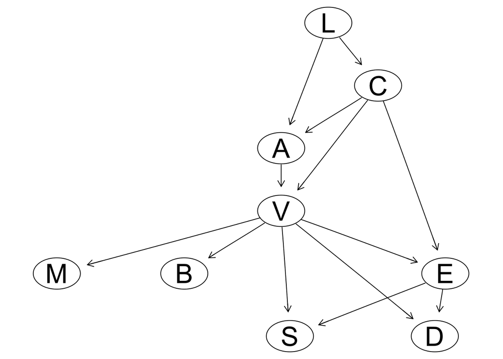

```r
optimal_dag = hc(data)
graphviz.plot(optimal_dag,shape = 'ellipse')
```

Esta DAG indican que la variable raíz es la población de la localidad en donde vive la persona, ésta informa su clase social y la cantidad de autos que tiene, que a su vez está dada por la clase social. La cantidad de autos junto con la clase social informan el vehículo en el que viaja la persona. El vehículo en el que viaja da la cantidad de motocicletas que poseé; junto con la clase social informa la edad; y junto con la edad informa el sexo y el día en el que viaja.

### Comparando las DAGS

Ahora antes de decidir qué estructura se utilizará para contestar las preguntas, se compararon las DAGs obteniendo sus puntajes en las pruebas de BIC (Bayesian Information Criterion) y AIC (Akaike Information Criterion).

```r
bic_dag_1 = score(dag,data = data, type = 'bic')
bic_dag_2 = score(dag2,data = data, type = 'bic')
bic_dag_3 = score(dag3,data = data, type = 'bic')
bic_opt_dag = score(optimal_dag, data = data, type = 'bic')

print(data.frame(DAG1 = bic_dag_1, DAG2 = bic_dag_2, DAG3 = bic_dag_3, OPTIMAL_DAG = bic_opt_dag))
```

```
      DAG1     DAG2     DAG3 OPTIMAL_DAG
1 -7049297 -6662052 -6883164    -6608780
```

```r
aic_dag_1 = score(dag,data = data, type = 'aic')
aic_dag_2 = score(dag2,data = data, type = 'aic')
aic_dag_3 = score(dag3,data = data, type = 'aic')
aic_opt_dag = score(optimal_dag, data = data, type = 'aic')

print(data.frame(DAG1 = aic_dag_1, DAG2 = aic_dag_2, DAG3 = aic_dag_3, OPTIMAL_DAG = aic_opt_dag))
```

```
      DAG1     DAG2     DAG3 OPTIMAL_DAG
1 -6688200 -6657074 -6700933    -6598911
```

Utilizando AIC se concluye de la misma forma que la mejor DAG es la obtenida a través de *Hill Climbing*, sin embargo se mustra la DAG basada en investigciones previas como la peor.

### Queries

Para entender propiamente como es que los factores socioeconómicos afectan los patrones de transporte de la población formulamos las siguientes preguntas:

1. ¿Cuál es la probabilidad de que una mujer joven (adultez joven y adolescencia) de estrato social alto use la bicicleta?

```r
bn_mle = bn.fit(dag, data =data, method = 'mle')
cpquery(bn_mle,(V=='7'),((S=='2')&((E=='3')|(E=='2'))&(C=='4')))
```

```
[1] 0.01018676
```

- La probabilidad de encontrar un evento de este tipo es bastante baja, siendo de alrededor de 1%. Mostrando que el uso de la bicicleta parece ser poco común en las mujeres de clase alta.
2. ¿Cuál es la probabilidad de que una persona que vive en una localidad de menos de 2,500 habitantes sea de estrato alto?

```r
cpquery(bn_mle, event = (E==4), evidence = (L==4), n = 10^6)
```

```
[1] 0.2957486
```

```r
cpquery(bn_mle, event = (A==1 | M==1 | B==1), evidence = (E==1 | E==2), n = 10^6)
```

```
[1] 0.4441436
```

```r
cpquery(bn_mle, event = ((V=='14')&(D=='1')), evidence = ((S=='2')&((E=='4')|(E=='5'))&(C=='1')), n = 10^6)
```

```
[1] 0.3008785
```

- Ahora calcularemos la probabilidad de los hombres.

```r
cpquery(bn_mle, event = ((V=='14')&(D=='1')), evidence = ((S=='1')&((E=='4')|(E=='5'))&(C=='1')), n = 10^6)
```

```
[1] 0.3043739
```

- Al comparar ambos resultados podemos rechazar el enunciado propuesto, puesto que las personas del sexo masculino tuvieron un mayor porcentaje, aunque la probabilidad es extremadamente cercana, dado que la diferencia es apenas de 0.35%.

## Conclusiones

La sección de resultados involucra la creación y posterior comparación de las DAGs, así como las respuestas a las queries asignadas utilizando la DAG seleccionada. La primera DAG fue creada con base en nuestras hipótesis, la cual representa las relaciones de dependencia entre las variables de interés, la segunda fue una versión mejorada respecto a la primera, dado que al realizar una prueba de de independencia condicional de los arcos formulados, fue posible eliminar dos relaciones cuyo aporte era casi nulo. Posteriormente se generó una tercer DAG a partir de un estudio e investigación previa, y por último se produjo la cuarta DAG utilizando el algoritmo Hill Climbing para conseguir la mejor estructura del grafo sobre los datos.

Todo lo mencionado previamente se vuelve de vital importancia debido a que entender cómo, quién y por qué se mueven los habitantes dentro de una metrópoli permite ampliar el panorama al momento de realizar diversas tareas públicas, por ejemplo, planificaciones sobre proyectos de movilidad vial, atención ciudadana, mejoramiento del transporte público, aliviar el flujo de vehículos en arterias principales y horas pico, proveer un acceso total y de calidad en cualquier tipo de servicio vial, y así de esta forma, lograr una urbanización óptima buscando la sustentabilidad y el aprovechamiento de los recursos que se poseen.

Una posible mejora a este trabajo sería poder acceder a una base de datos más reciente, dado que la información adquirida es del 2017, por lo que los resultados pueden no representar de la mejor manera la actualidad en la movilidad de los capitalinos, del mismo modo los archivos que contenían la información no proporcionaban claridad respecto al significado de muchas variables, por lo que se obstaculiza el proceso y análisis para una mejor comprensión de los datos.

## References

Bosisio, Andrea, and Rubén Talavera García. 2025. “Impacto Del COVID-19 En La Movilidad En Transporte Público de Ciudades Intermedias: El Caso de La Ciudad de Santa Fe de La Vera Cruz, Argentina.” *Geográfica Digital* 22 (43): 52–68. https://doi.org/10.30972/geo.22438227.

Dissanayake, Dilum, and Takayuki Morikawa. 2010. “Investigating Household Vehicle Ownership, Mode Choice and Trip Sharing Decisions Using a Combined Revealed Preference/Stated Preference Nested Logit Model: Case Study in Bangkok Metropolitan Region.” *Journal of Transport Geography - J TRANSP GEOGR* 18 (May): 402–10. https://doi.org/10.1016/j.jtrangeo.2009.07.003.

Garrido Guillén, Javier E. 2025. *Módulo 1: Redes Bayesianas Multinomiales. Análisis de Métodos de Razonamiento e Incertidumbre, Gpo 102 - AD 2025*.

Raux, Charles, Tai-Yu Ma, and Eric Cornelis. 2016. “Variability in Daily Activity-Travel Patterns: The Case of a One-Week Travel Diary.” *European Transport Research Review* 8 (December). https://doi.org/10.1007/s12544-016-0213-9.

Rith, Monorom, Alexis Fillone, and Jose Bienvenido M. Biona. 2019. “The Impact of Socioeconomic Characteristics and Land Use Patterns on Household Vehicle Ownership and Energy Consumption in an Urban Area with Insufficient Public Transport Service – a Case Study of Metro Manila.” *Journal of Transport Geography* 79: 102484. https://doi.org/https://doi.org/10.1016/j.jtrangeo.2019.102484.

Timpabi, Akua, Osei Kwakwa, and Charles Anum Adams. 2021. “Bicycle Ownership and Utilization in Tamale Metropolis; Influencing Factors and Impacts to Sustainable Transport.” *Heliyon* 7 (June): e07133. https://doi.org/10.1016/j.heliyon.2021.e07133.

Yang, Hung-Chia, Ling Jin, Alina Lazar, Annika Todd-Blick, Alex Sim, Kesheng Wu, Qianmiao Chen, and C. Anna Spurlock. 2023. “Gender Gaps in Mode Usage, Vehicle Ownership, and Spatial Mobility When Entering Parenthood: A Life Course Perspective.” *Systems* 11 (6). https://doi.org/10.3390/systems11060314.

Yang, Min, Dan Li, Wei Wang, Jingyao Zhao, and Xuewu Chen. 2013. “Modeling Gender-Based Differences in Mode Choice Considering Time-Use Pattern: Analysis of Bicycle, Public Transit, and Car Use in Suzhou, China.” *Advances in Mechanical Engineering* 5: 706918. https://doi.org/10.1155/2013/706918.

Zhang, Yi, Chaoyang Li, Eddie Liu, and Wei Wu. 2018. “The Socioeconomic Characteristics, Urban Built Environment and Household Car Ownership in a Rapidly Growing City: Evidence from Zhongshan, China.” *Journal of Asian Architecture and Building Engineering* 17 (January): 133–40. https://doi.org/10.3130/jaabe.17.133.